# Estudios de Informática, Multimedia y Telecomunicaciones

# Minería de datos: PEC3 - Clasificación con árboles de decisión

Autor: Alberto Sánchez Mazarro

Mayo 2020

# 1 Introducción

## 1.1 Presentación

Esta prueba de evaluación continua cubre los Módulos 3 (Clasificación: árboles de decisión) y el Módulo 8 (Evaluación de modelos) del programa de la asignatura.

## 1.2 Competencias

Las competencias que se trabajan en esta prueba son:

- Uso y aplicación de las TIC en el ámbito académico y profesional.
- Capacidad para innovar y generar nuevas ideas.
- Capacidad para evaluar soluciones tecnológicas y elaborar propuestas de proyectos teniendo en cuenta los recursos, las alternativas disponibles y las condiciones de mercado.
- Conocer las tecnologías de comunicaciones actuales y emergentes así como saberlas aplicar convenientemente para diseñar y desarrollar soluciones basadas en sistemas y tecnologías de la información.
- Aplicación de las técnicas específicas de ingeniería del software en las diferentes etapas del ciclo de vida de un proyecto.
- Capacidad para aplicar las técnicas específicas de tratamiento, almacenamiento y administración de datos.
- Capacidad para proponer y evaluar diferentes alternativas tecnológicas para resolver un problema concreto.

## 1.3 Objetivos

La correcta asimilación del Módulo 3. En esta PEC trabajaremos la generación e interpretación de un árbol de decisión con el software de prácticas. Seguiremos también con la preparación de los datos y la extracción inicial de conocimiento.

## 1.4 Descripción de la PEC a realizar

La prueba está estructurada en un total de un único ejercicio práctico.

## 1.5 Recursos Básicos

**Material docente proporcionado por la UOC.**

Módulo 3 y 8 del material didáctico.

**Complementarios**

- Los descritos para la anterior PEC.
- Fichero titanic.csv
- R package C5.0 (Decision Trees and Rule-Based Models): https://cran.r-project.org/web/packages/C50/index.html

## 1.6 Criterios de valoración

Todos los ejercicios deben ser presentados de forma razonada y clara, especificando todos y cada uno de los pasos que se hayan llevado a cabo para su resolución. No se aceptará ninguna respuesta que no esté claramente justificada.

## 1.7 Formato y fecha de entega

El formato de entrega es: usernameestudiant-PECn.html/doc/docx/odt/pdf. Se recomienda la entrega en formato html y también el Rmd que genera el html entregado. Fecha de Entrega: 20/05/2020. Se debe entregar la PEC en el buzón de entregas del aula.

## 1.8 Nota: Propiedad intelectual

> A menudo es inevitable, al producir una obra multimedia, hacer uso de recursos creados por terceras personas. Es por lo tanto comprensible hacerlo en el marco de una práctica de los estudios de Informática, Multimedia y Telecomunicación de la UOC, siempre y cuando esto se documente claramente y no suponga plagio en la práctica.

> Por lo tanto, al presentar una práctica que haga uso de recursos ajenos, se debe presentar junto con ella un documento en qué se detallen todos ellos, especificando el nombre de cada recurso, su autor, el lugar dónde se obtuvo y su estatus legal: si la obra está protegida por el copyright o se acoge a alguna otra licencia de uso (Creative Commons, licencia GNU, GPL …). El estudiante deberá asegurarse de que la licencia no impide específicamente su uso en el marco de la práctica. En caso de no encontrar la información correspondiente tendrá que asumir que la obra está protegida por copyright.

> Deberéis, además, adjuntar los ficheros originales cuando las obras utilizadas sean digitales, y su código fuente si corresponde.

# 2 Enunciado

En este ejercicio vamos a seguir los pasos del ciclo de vida de un proyecto de minería de datos, para el caso de un algoritmo de clasificación y más concretamente un árbol de decisión. Lo haremos con el archivo titanic.csv, que se encuentra adjunto en el aula. Este archivo contiene un registro por cada pasajero que viajaba en el Titanic. En las variables se caracteriza si era hombre o mujer, adulto o menor (niño), en qué categoría viajaba o si era miembro de la tripulación.

Objetivos:

- Estudiar los datos, por ejemplo: ¿Número de registros del fichero? ¿Distribuciones de valores por variables? ¿Hay campos mal informados o vacíos?
- Preparar los datos. En este caso ya están en el formato correcto y no es necesario discretizar ni generar atributos nuevos. Hay que elegir cuáles son las variables que se utilizarán para construir el modelo y cuál es la variable que clasifica. En este caso la variable por la que clasificaremos es el campo de si el pasajero sobrevivió o no.
- Instalar, si es necesario, el paquete C5.0 Se trata de una implementación más moderna del algoritmo ID3 de Quinlan. Tiene los principios teóricos del ID3 más la poda automática. Con este paquete generar un modelo de minería.
- ¿Cuál es la calidad del modelo?
- Generar el árbol gráfico.
- Generar y extraer las reglas del modelo.
- En función del modelo, el árbol y las reglas: ¿Cuál es el conocimiento que obtenemos?
- Probar el modelo generado presentándole nuevos registros. ¿Clasifica suficientemente bien?

# 3 Ejercicios

## 3.1 Ejercicio 1:

Partiendo del ejemplo mostrado, repetid el ejercicio con otro conjunto de datos. Pueden ser datos reales de vuestro ámbito laboral o de algún repositorio de datos de Internet. Mirad por ejemplo: http://www.ics.uci.edu/~mlearn/MLSummary.html i http://www.kaggle.com.

Es muy importante seleccionar correctamente el conjunto de datos y explicar de forma correcta la base de datos y la razón de su elección.

Podéis añadir o variar los puntos si lo consideráis necesario (por ejemplo, crear el modelo con todos los datos y validación cruzada, probar el boosting o variar el prunning …) Recordad también que el ciclo de vida de los proyectos de minería contempla retroceder para volver a generar el modelo con datos modificados o parámetros del algoritmo variados si el resultado no es lo suficientemente bueno.

### 3.1.1 Respuesta 1:

El conjunto de datos elegido es Wholesale customer data. Ha sido seleccionado de (http://archive.ics.uci.edu/ml/datasets/Wholesale+customers)

Este conjunto de datos creo que es especialmente interesante para árboles de clasificación. Muestra la información de compra de diferentes empresas portuguesas que pueden ser hoteles-restaurantes o cadenas de retail. Además, pueden estar encuadradas en la región de Lisboa, Oporto u otras.

En él se presenta un conjunto de datos numéricos con las siguientes características:

8 atributos:

1. CHANNEL: Hotel/Restaurant/Café o Retail channel (Supermercado)
2. REGION: Lisboa (1), Oporto (2) u Otra (3)
3. FRESH: gasto anual (en una unidad monetaria) en productos frescos
4. MILK: gasto anual en leche;
5. GROCERY: gasto anual en comestibles;
6. FROZEN: gasto anual en congelados
7. DETERGENTS_PAPER: gasto anual en detergentes y papel (Continuous)
8. DELICATESSEN: gasto anual en productos de delicatessen (Continuous);

De ellos, los 6 últimos atributos indican el gasto en unidades monetarias del establecimiento (diremos euros, por simplificar) y los dos primeros son variables de clase , donde “Channel” indican si el establecimiento es “Hotel/Restaurante” o “Retail” y “Region” indica si se está ubicada en el área de Lisboa, Oporto u otra.

La idea aquí es tratar de predecir en función de las variables si un determinado establecimiento es Hotel/Restaurante o Retail.

Nótese que el atributo “REGION”, en principio se utilizará como un elemento más en el árbol, pero también se hará el ejercicio de tratarlo como la variable sobre la que realizar la predicción, incluyendo el tipo de establecimiento como variable de decisión; es decir, vamos a intentar hacer dos predicciones: la del tipo de establecimiento y la de la región.

```r
datos <- read.csv('/Users/Alberto/UOC/Minería/PEC3/Wholesale customers data.csv',stringsAsFactors = FALSE, header = TRUE)

library(rpart)
library(rpart.plot)
library(grid)
library(gridExtra)
library(caret)
library(dplyr)
library(class)
```

Un vez cargado el dataset vamos a hacer una primera inspección de los datos.

```r
#Vemos la dimensión del dataset
dim(datos)
```

```
## [1] 440   8
```

```r
#Un resumen
summary(datos)
```

```
##     Channel          Region          Fresh             Milk
##  Min.   :1.000   Min.   :1.000   Min.   :     3   Min.   :   55
##  1st Qu.:1.000   1st Qu.:2.000   1st Qu.:  3128   1st Qu.: 1533
##  Median :1.000   Median :3.000   Median :  8504   Median : 3627
##  Mean   :1.323   Mean   :2.543   Mean   : 12000   Mean   : 5796
##  3rd Qu.:2.000   3rd Qu.:3.000   3rd Qu.: 16934   3rd Qu.: 7190
##  Max.   :2.000   Max.   :3.000   Max.   :112151   Max.   :73498
##     Grocery          Frozen        Detergents_Paper    Delicassen
##  Min.   :    3   Min.   :   25.0   Min.   :    3.0   Min.   :    3.0
##  1st Qu.: 2153   1st Qu.:  742.2   1st Qu.:  256.8   1st Qu.:  408.2
##  Median : 4756   Median : 1526.0   Median :  816.5   Median :  965.5
##  Mean   : 7951   Mean   : 3071.9   Mean   : 2881.5   Mean   : 1524.9
##  3rd Qu.:10656   3rd Qu.: 3554.2   3rd Qu.: 3922.0   3rd Qu.: 1820.2
##  Max.   :92780   Max.   :60869.0   Max.   :40827.0   Max.   :47943.0
```

```r
#La estructura
str(datos)
```

```
## 'data.frame':    440 obs. of  8 variables:
##  $ Channel         : int  2 2 2 1 2 2 2 2 1 2 ...
##  $ Region          : int  3 3 3 3 3 3 3 3 3 3 ...
##  $ Fresh           : int  12669 7057 6353 13265 22615 9413 12126 7579 5963 6006 ...
##  $ Milk            : int  9656 9810 8808 1196 5410 8259 3199 4956 3648 11093 ...
##  $ Grocery         : int  7561 9568 7684 4221 7198 5126 6975 9426 6192 18881 ...
##  $ Frozen          : int  214 1762 2405 6404 3915 666 480 1669 425 1159 ...
##  $ Detergents_Paper: int  2674 3293 3516 507 1777 1795 3140 3321 1716 7425 ...
##  $ Delicassen      : int  1338 1776 7844 1788 5185 1451 545 2566 750 2098 ...
```

De una primera observación vemos lo siguiente:

- Tenemos 440 registros con 8 columnas cada una.
- Todos los datos están representados en números enteros, lo que supone un problema al aplicar las técnicas de árboles de clasificación.
- No disponemos de valores nulos.

En todo caso, “Channel” (1,2) y “Region” (1,2,3) están en enteros porque es el convenio adoptado. Pero en realidad podría haberse adoptado cualquier tipo de datos para representarlos.

Lo vamos a hacer por comodidad.

```r
datos$Channel <- gsub('1', 'Hotel', datos$Channel )
datos$Channel <- gsub('2', 'Retail', datos$Channel )
datos$Region <- gsub('1', 'Lisboa', datos$Region )
datos$Region <- gsub('2', 'Oporto', datos$Region )
datos$Region <- gsub('3', 'Otra', datos$Region )
datos$Channel<-as.factor(datos$Channel)
datos$Region<-as.factor(datos$Region)

#Hago una copia de los datos que utilizaremos después.
datosCopia<-datos
```

Con el resto de columnas (las variables que pretendemos utilizar para ir conformando el árbol de decisión), observamos que contienen valores enteros por lo que es necesario discretizar las variables. Para ello emplearé diferentes técnicas estudiadas previamente.

Ahora vamos a trabajar con el algoritmo C50 de modo similar al ejemplo.

Lo primero que vamos a hacer es discretizar los valores. Para ello, inicialmente vamos a separar cada parámetro en Alto/bajo tomando como valor referencia la media de las observaciones (lo que esté por encima de la media tendrá un valor y lo que esté por debajo tendrá otro). Nótese que esto no implica que los dos valores tengan el mismo número de elementos por cada variable.

```r
 clasificarPorMedia <- function (x,y){
 if(x<y) {"Bajo"}
 else {"Alto"}
 }
mediaMilk<-mean(datos$Milk)
mediaFresh<-mean(datos$Fresh)
mediaGrocery<-mean(datos$Grocery)
mediaFrozen<-mean(datos$Frozen)
mediaDetergents<-mean(datos$Detergents_Paper)
mediaDelicassen<-mean(datos$Delicassen)

for (i in 1: nrow(datos)){
  datos$Leche[i]<-clasificarPorMedia(datos$Milk[i],mediaMilk)
}
for (i in 1: nrow(datos)){
  datos$Frescos[i]<-clasificarPorMedia(datos$Fresh[i],mediaFresh)
}
for (i in 1: nrow(datos)){
  datos$Congelados[i]<-clasificarPorMedia(datos$Frozen[i],mediaFrozen)
}
for (i in 1: nrow(datos)){
  datos$Comestibles[i]<-clasificarPorMedia(datos$Grocery[i],mediaGrocery)
}
for (i in 1: nrow(datos)){
  datos$Detergente[i]<-clasificarPorMedia(datos$Detergents_Paper[i],mediaDetergents)
}
for (i in 1: nrow(datos)){
  datos$Delicias[i]<-clasificarPorMedia(datos$Delicassen[i],mediaDelicassen)
}
datos$Leche<-as.factor(datos$Leche)
datos$Frescos<-as.factor(datos$Frescos)
datos$Congelados<-as.factor(datos$Congelados)
datos$Detergente<-as.factor(datos$Detergente)
datos$Delicias<-as.factor(datos$Delicias)
datos$Comestibles<-as.factor(datos$Comestibles)
```

Una vez tenemos los datos en variables discretas vamos a analizar los resultados preliminares con diagramas de barras por cada variable.

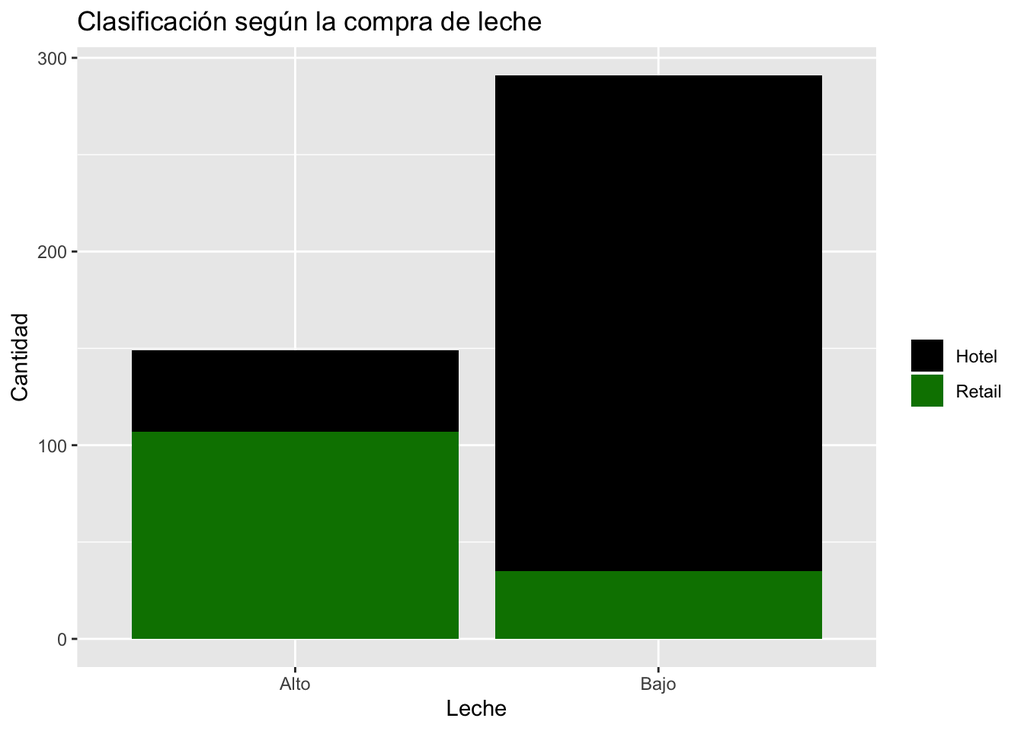

```r
ggplot(datos,aes(Leche,fill=Channel))+geom_bar() +labs(x="Leche", y="Cantidad")+ guides(fill=guide_legend(title=""))+ scale_fill_manual(values=c("black","#008000"))+ggtitle("Clasificación según la compra de leche")
```

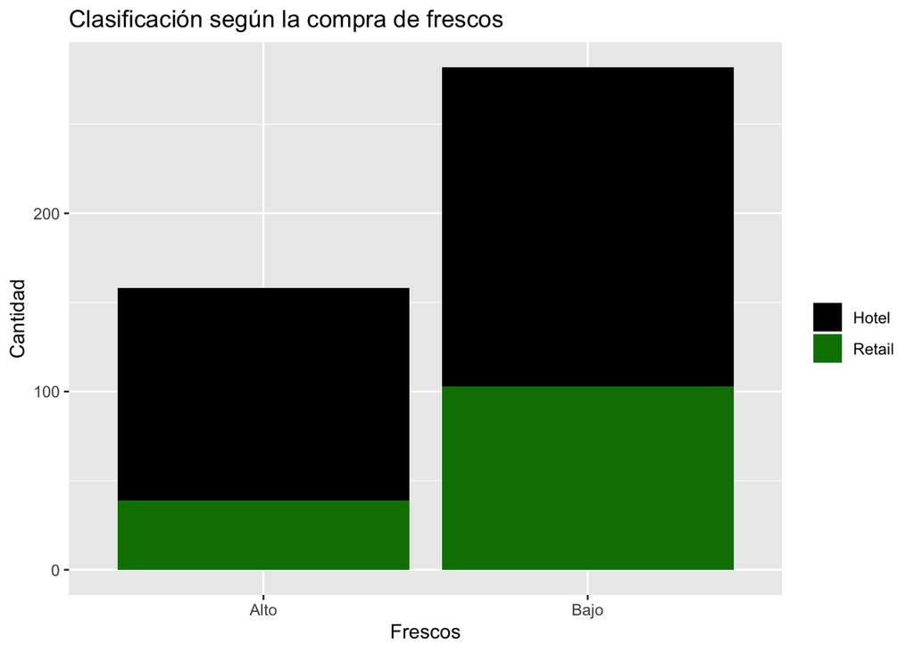

```r
ggplot(datos,aes(Frescos,fill=Channel))+geom_bar() +labs(x="Frescos", y="Cantidad")+ guides(fill=guide_legend(title=""))+ scale_fill_manual(values=c("black","#008000"))+ggtitle("Clasificación según la compra de frescos")
```

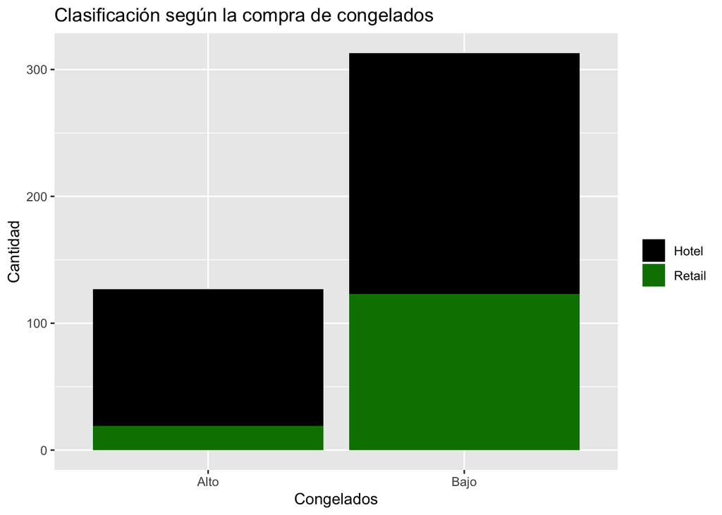

```r
ggplot(datos,aes(Congelados,fill=Channel))+geom_bar() +labs(x="Congelados", y="Cantidad")+ guides(fill=guide_legend(title=""))+ scale_fill_manual(values=c("black","#008000"))+ggtitle("Clasificación según la compra de congelados")
```

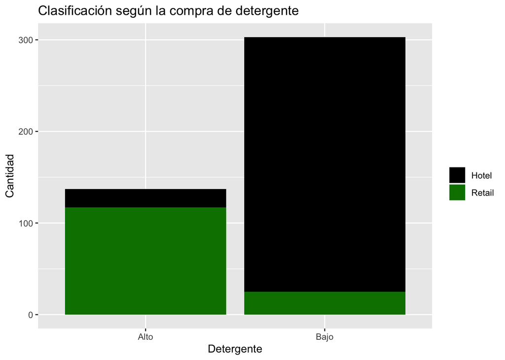

```r
ggplot(datos,aes(Detergente,fill=Channel))+geom_bar() +labs(x="Detergente", y="Cantidad")+ guides(fill=guide_legend(title=""))+ scale_fill_manual(values=c("black","#008000"))+ggtitle("Clasificación según la compra de detergente")
```

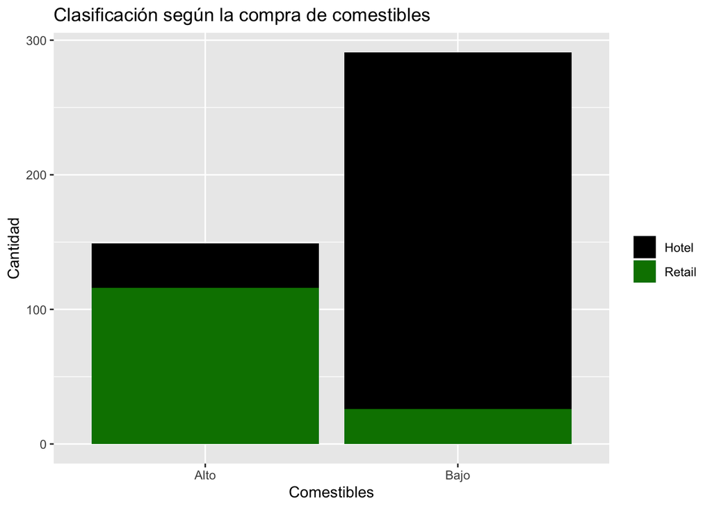

```r
ggplot(datos,aes(Comestibles,fill=Channel))+geom_bar() +labs(x="Comestibles", y="Cantidad")+ guides(fill=guide_legend(title=""))+ scale_fill_manual(values=c("black","#008000"))+ggtitle("Clasificación según la compra de comestibles")
```

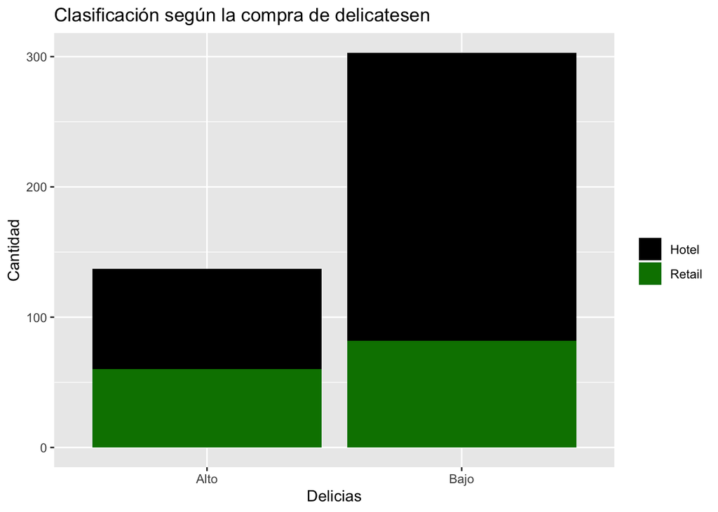

```r
ggplot(datos,aes(Delicias,fill=Channel))+geom_bar() +labs(x="Delicias", y="Cantidad")+ guides(fill=guide_legend(title=""))+ scale_fill_manual(values=c("black","#008000"))+ggtitle("Clasificación según la compra de delicatesen")
```

De una primera inspección se observa que:

- Cuando el gasto en “Grocery”, Detergente o leche es bajo, normalmente se trata de un hotel.
- Las medidas de gasto en productos frescos están muy repartidas entre los dos tipos de establecimiento.
- Con respecto a los congelados, los retail suelen tener un gasto bajo; en los hoteles no es un factor determinante.

Vamos a verlo en forma de tabla:

```r
tabla_Grocery <- table(datos$Comestibles, datos$Channel)
tabla_Grocery
```

```
##
##        Hotel Retail
##   Alto    33    116
##   Bajo   265     26
```

```r
tabla_Leche<- table (datos$Leche, datos$Channel)
tabla_Leche
```

```
##
##        Hotel Retail
##   Alto    42    107
##   Bajo   256     35
```

```r
tabla_Detergente<- table (datos$Detergente, datos$Channel)
tabla_Detergente
```

```
##
##        Hotel Retail
##   Alto    20    117
##   Bajo   278     25
```

```r
tabla_Congelados<- table (datos$Congelados, datos$Channel)
tabla_Congelados
```

```
##
##        Hotel Retail
##   Alto   108     19
##   Bajo   190    123
```

A partir de aquí, vamos a tratar de generar el árbol de decisión.

Para ello vamos a generar dos conjuntos: de entrenamiento y de prueba. Como los datos no siguen ningún patrón fijo, no es preciso desordenarlos.

De los 440 registros de que disponemos, vamos a utilizar 300 para el entrenamiento y 140 para prueba.

```r
#Columna con el objetivo(Channel)
resultado <- datos[,1]
#Columnas con los valores categorizados
variables <- datos[,9:14]

#Datos de entrenamiento
datos_Train <- datos[1:300,]
#Datos de Test
datos_Test <- datos[301:440,]

trainResultado <- resultado[1:300]
trainVariables <- variables[1:300,]

testResultado <- resultado[301:440]
testVariables <- variables[301:440,]
```

Vamos a crear el árbol del modelo:

```r
model <- C50::C5.0(trainVariables, trainResultado,rules=TRUE )
summary(model)
```

```
##
## Call:
## C5.0.default(x = trainVariables, y = trainResultado, rules = TRUE)
##
##
## C5.0 [Release 2.07 GPL Edition]      Fri May 15 08:46:29 2020
## -------------------------------
##
## Class specified by attribute `outcome'
##
## Read 300 cases (7 attributes) from undefined.data
##
## Rules:
##
## Rule 1: (201/18, lift 1.4)
##  Detergente = Bajo
##  ->  class Hotel  [0.906]
##
## Rule 2: (99/14, lift 2.5)
##  Detergente = Alto
##  ->  class Retail  [0.851]
##
## Default class: Hotel
##
##
## Evaluation on training data (300 cases):
##
##          Rules
##    ----------------
##      No      Errors
##
##       2   32(10.7%)   <<
##
##
##     (a)   (b)    <-classified as
##    ----  ----
##     183    14    (a): class Hotel
##      18    85    (b): class Retail
##
##
##  Attribute usage:
##
##  100.00% Detergente
##
##
## Time: 0.0 secs
```

Vemos que obtenemos un 89% de acierto solo con la compra de detergente, que parece claramente el atributo más importante para realizar la diferenciación.

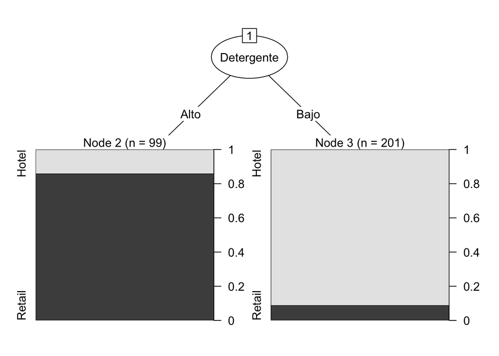

```r
model <- C50::C5.0(trainVariables, trainResultado)
plot(model)
```

Anaizamos la calidad del modelo:

```r
predicted_model <- predict( model, testVariables, type="class" )
print(sprintf("La precisión del árbol es: %.4f %%",100*sum(predicted_model == testResultado) / length(predicted_model)))
```

```
## [1] "La precisión del árbol es: 90.7143 %"
```

```r
table(datos_Test[["Channel"]],Predicted=predicted_model)
```

```
##         Predicted
##          Hotel Retail
##   Hotel     95      6
##   Retail     7     32
```

```r
confusionMatrix(predicted_model, datos_Test[["Channel"]])
```

```
## Confusion Matrix and Statistics
##
##           Reference
## Prediction Hotel Retail
##     Hotel     95      7
##     Retail     6     32
##
##                Accuracy : 0.9071
##                  95% CI : (0.8464, 0.9496)
##     No Information Rate : 0.7214
##     P-Value [Acc > NIR] : 5.74e-08
##
##                   Kappa : 0.7671
##
##  Mcnemar's Test P-Value : 1
##
##             Sensitivity : 0.9406
##             Specificity : 0.8205
##          Pos Pred Value : 0.9314
##          Neg Pred Value : 0.8421
##              Prevalence : 0.7214
##          Detection Rate : 0.6786
##    Detection Prevalence : 0.7286
##       Balanced Accuracy : 0.8806
##
##        'Positive' Class : Hotel
##
```

```r
mat_conf<-table(testResultado,Predicted=predicted_model)
porcentaje_correct<-100 * sum(diag(mat_conf)) / sum(mat_conf)
print(sprintf("El %% de registros correctamente clasificados es: %.4f %%",porcentaje_correct))
```

```
## [1] "El % de registros correctamente clasificados es: 90.7143 %"
```

```r
mat_conf
```

```
##              Predicted
## testResultado Hotel Retail
##        Hotel     95      6
##        Retail     7     32
```

Vamos a ver, por curiosidad, qué sucedería si hacemos el entrenamiento sin la variable “Detergente”, solo para ver cómo se genera el árbol y qué otros atributos tienen cierto peso:

```r
variablesSinDetergente<-select(datos, Leche, Frescos, Congelados, Delicias, Comestibles)
trainVariablesSinDetergente <- variablesSinDetergente[1:300,]
model <- C50::C5.0(trainVariablesSinDetergente, trainResultado,rules=TRUE )
summary(model)
```

```
##
## Call:
## C5.0.default(x = trainVariablesSinDetergente, y = trainResultado, rules = TRUE)
##
##
## C5.0 [Release 2.07 GPL Edition]      Fri May 15 08:46:30 2020
## -------------------------------
##
## Class specified by attribute `outcome'
##
## Read 300 cases (6 attributes) from undefined.data
##
## Rules:
##
## Rule 1: (197/20, lift 1.4)
##  Comestibles = Bajo
##  ->  class Hotel  [0.894]
##
## Rule 2: (103/20, lift 2.3)
##  Comestibles = Alto
##  ->  class Retail  [0.800]
##
## Default class: Hotel
##
##
## Evaluation on training data (300 cases):
##
##          Rules
##    ----------------
##      No      Errors
##
##       2   40(13.3%)   <<
##
##
##     (a)   (b)    <-classified as
##    ----  ----
##     177    20    (a): class Hotel
##      20    83    (b): class Retail
##
##
##  Attribute usage:
##
##  100.00% Comestibles
##
##
## Time: 0.0 secs
```

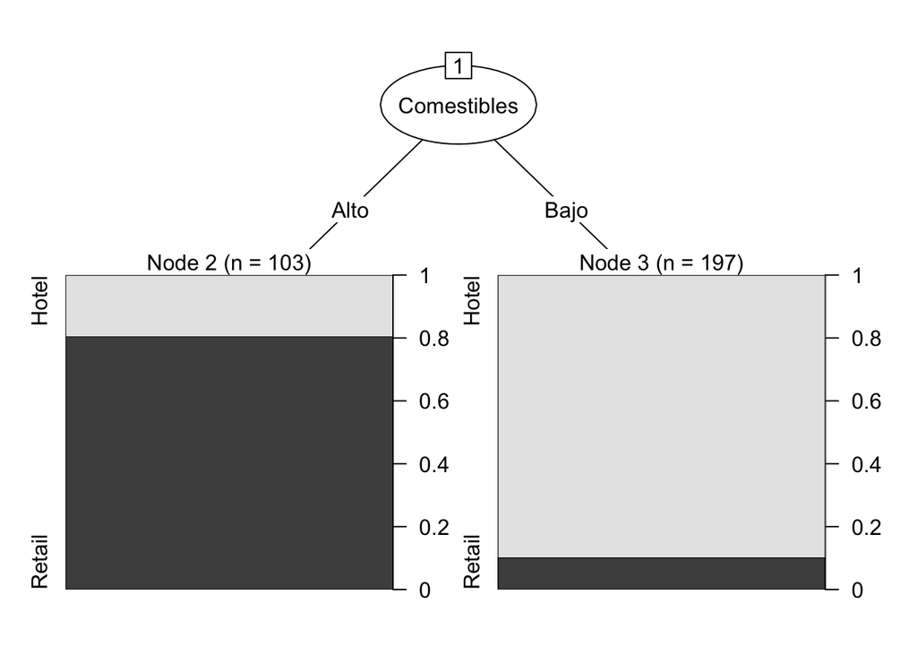

```r
model <- C50::C5.0(trainVariablesSinDetergente, trainResultado)
plot(model)
```

De nuevo vemos que tenemos una única variable “dominante”, que en este caso es “Comestibles”. De nuevo los resultados son bastante bueno, pero hay que notar que lo que puede que no sea demasiado buena sea la división inicial (dividir por la media es una decisión cuestionable).

Vamos a dividir los detergentes y comestibles en cuatro grupos (por sus cuartiles y vamos a generar de nuevo el árbol):

```r
 clasificarPorCuartil <- function (valor,array){
 if(valor<quantile(array,0.25)) {"B"}
 else  if(valor<quantile(array,0.5)) {"MB"}
else  if(valor<quantile(array,0.75)) {"MA"}
   else{"A"}
 }


for (i in 1:nrow(trainVariables)){
  trainVariables$ComestiblesAux[i]<-clasificarPorCuartil(datosCopia$Grocery[i],datos$Grocery)
}

for (i in 1:nrow(testVariables)){
  testVariables$ComestiblesAux[i]<-clasificarPorCuartil(datosCopia$Grocery[i+nrow(trainVariables)],datos$Grocery)
}

for (i in 1:nrow(trainVariables)){
  trainVariables$DetergentesAux[i]<-clasificarPorCuartil(datos$Detergents_Paper[i],datos$Detergents_Paper)
}

for (i in 1:nrow(testVariables)){
  testVariables$DetergentesAux[i]<-clasificarPorCuartil(datos$Detergents_Paper[i+nrow(trainVariables)],datos$Detergents_Paper)
}
```

Vamos a dejar en el dataSet las columnas por cuartiles de detergente y Grocery mientras que el resto las dejamos solo como “Alto” o Bajo"

Para que apareciera mejor en el arbol se ha tomado el convenio de notación: B->Bajo, MB->Medio Bajo, MA->Medio Alto, A->Alto

```r
variablesConCuartiles<-rbind(trainVariables, testVariables)

variablesConCuartiles$ComestiblesAux<-as.factor(variablesConCuartiles$ComestiblesAux)
variablesConCuartiles$DetergentesAux<-as.factor(variablesConCuartiles$DetergentesAux)

#Dejamos todas las variables con la media salvo Grocery y Leche (por cuartiles)
variablesConCuartiles<-select(variablesConCuartiles, Leche, Frescos, Congelados, Delicias, ComestiblesAux, DetergentesAux)

trainVariablesConCuartiles <- variablesConCuartiles[1:300,]
testVariablesConCuartiles <- variablesConCuartiles[301:440,]

model <- C50::C5.0(trainVariablesConCuartiles, trainResultado,rules=TRUE )
summary(model)
```

```
##
## Call:
## C5.0.default(x = trainVariablesConCuartiles, y = trainResultado, rules = TRUE)
##
##
## C5.0 [Release 2.07 GPL Edition]      Fri May 15 08:46:31 2020
## -------------------------------
##
## Class specified by attribute `outcome'
##
## Read 300 cases (7 attributes) from undefined.data
##
## Rules:
##
## Rule 1: (144/2, lift 1.5)
##  ComestiblesAux in {B, MB}
##  ->  class Hotel  [0.979]
##
## Rule 2: (144/3, lift 1.5)
##  DetergentesAux in {B, MB}
##  ->  class Hotel  [0.973]
##
## Rule 3: (188/21, lift 1.3)
##  Leche = Bajo
##  ->  class Hotel  [0.884]
##
## Rule 4: (80/6, lift 2.7)
##  ComestiblesAux in {A, MA}
##  DetergentesAux = A
##  ->  class Retail  [0.915]
##
## Rule 5: (156/55, lift 1.9)
##  ComestiblesAux in {A, MA}
##  ->  class Retail  [0.646]
##
## Default class: Hotel
##
##
## Evaluation on training data (300 cases):
##
##          Rules
##    ----------------
##      No      Errors
##
##       5   24( 8.0%)   <<
##
##
##     (a)   (b)    <-classified as
##    ----  ----
##     185    12    (a): class Hotel
##      12    91    (b): class Retail
##
##
##  Attribute usage:
##
##  100.00% ComestiblesAux
##   74.67% DetergentesAux
##   62.67% Leche
##
##
## Time: 0.0 secs
```

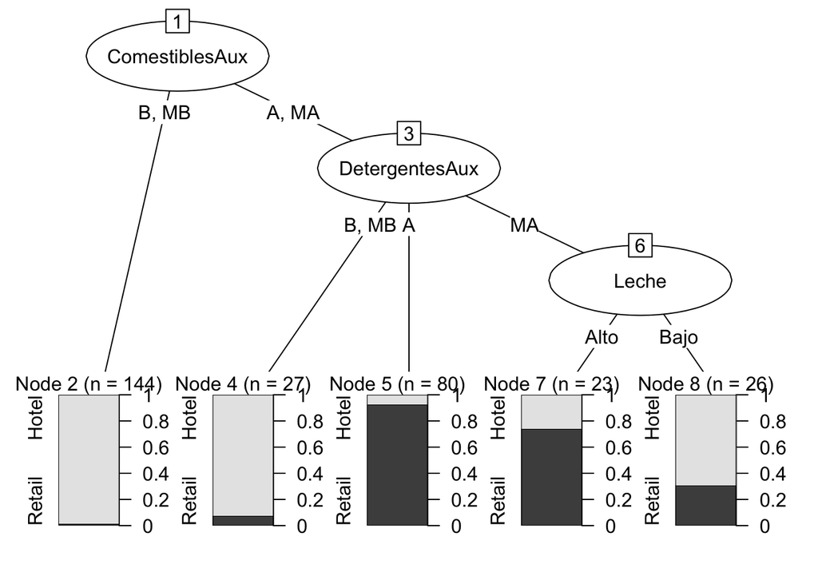

```r
model <- C50::C5.0(trainVariablesConCuartiles, trainResultado)
plot(model)
```

Vemos varias reglas similares a lo que habíamos visto anteriormente.

```r
predicted_model <- predict( model, testVariablesConCuartiles, type="class" )
print(sprintf("La precisión del árbol es: %.4f %%",100*sum(predicted_model == testResultado) / length(predicted_model)))
```

```
## [1] "La precisión del árbol es: 90.7143 %"
```

Aquí obtenemos resultados que siguen demostrando que las variables más importantes son las mismas que antes pero también se incorpora la leche.

```r
mat_conf<-table(testResultado,Predicted=predicted_model)
porcentaje_correct<-100 * sum(diag(mat_conf)) / sum(mat_conf)
print(sprintf("El %% de registros correctamente clasificados es: %.4f %%",porcentaje_correct))
```

```
## [1] "El % de registros correctamente clasificados es: 90.7143 %"
```

**Trabajo con otro tipo de árbol**

Lo primero que vamos a intentar (antes de manipular los datos) es ver el árbol de decisión completo con todos estos datos:

La librería rpart nos petmite crear un árbol con una variable objetivo (en este caso Channel) y ver el árbol que se genera utilizando el algoritmo CART.

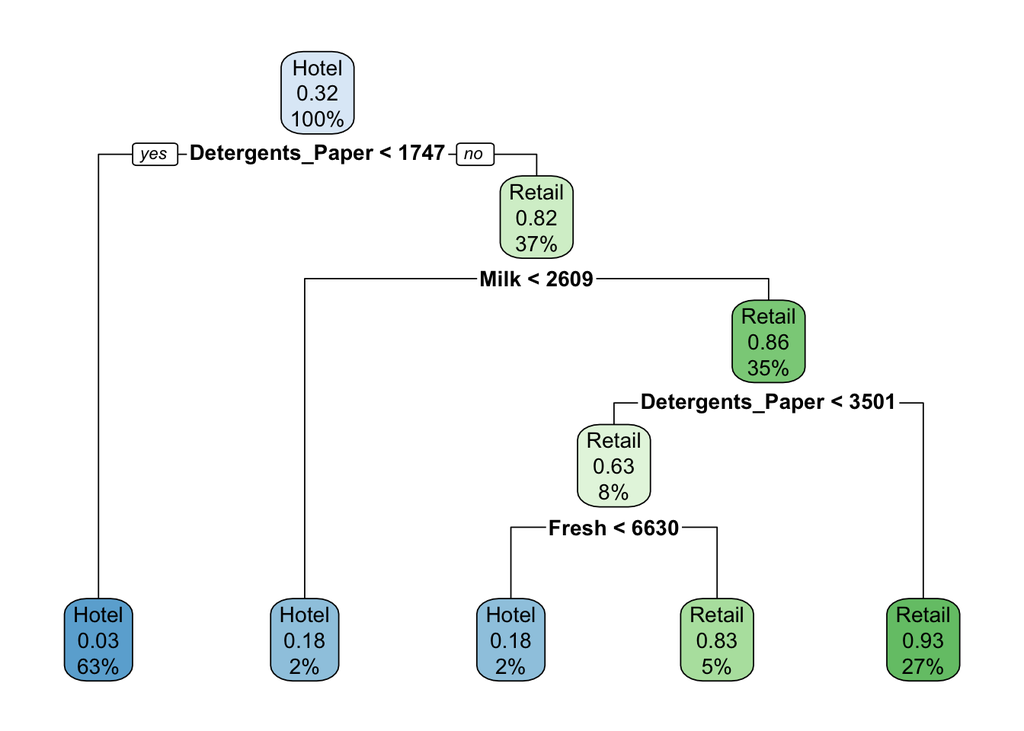

```r
#Volvemos a copiar en "datos" los datos originales sin manipular.
datos<-datosCopia

arbolCompletoChannel <- rpart(formula =Channel ~ ., data = datos, method = "class")
rpart.plot(arbolCompletoChannel)
```

La forma de interpretar este árbol es la siguiente:

Por ejemplo, en el nodo inferior izquierdo (que abarca el 63% de los casos totales), vemos que si la cantidad de papel y detergente está por debajo de un determinado número, en el 97% de los casos estamos ante un hotel.

Mientras, en el nodo inferior derecho (el 27% de los casos totales), cuando se cumplen las tres condiciones que hacen llegar hasta este nodo, en 93% de los casos se trata de un retail.

Vamos a hacer lo mismo con la regiones. En todo caso, no aspiramos a encontrar unos datos “tan lógicos” como antes, puesto que parece más razonable que las cantidades compradas de cada material se relacionen más con el tipo de establecimiento que con la región.

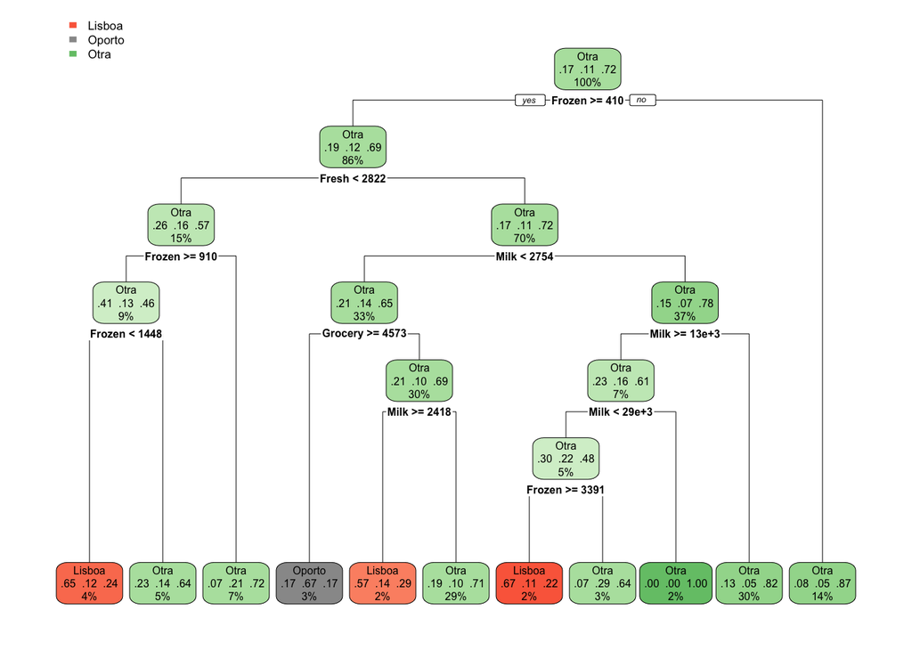

```r
arbolCompletoRegion <- rpart(formula =Region ~ ., data = datos, method = "class")
rpart.plot(arbolCompletoRegion)
```

Sin entrar a analizar “la semántica”, vemos que el árbol es “más complejo” puesto que las variables utilizadas no sirven para realizar separaciones tan significativas como buscando por tipo de establecimiento. A partir de ahora, vamos a trabajar solo con el primer caso “Channel”.

Vamos a crear conjuntos de entrenamiento y de prueba para el conjunto que tenemos todavía con variables continuas y sin manipular:

```r
datos_Train <- datos[1:300,]
datos_Test <- datos[301:440,]
```

Calculamos el árbol de entrenamiento

```r
arbolTrain <- rpart(formula = Channel ~ ., data = datos_Train)
```

Calculamos la predicción almacenando los datos en el vector prediccionCART

```r
prediccionCART <- predict(arbolTrain, newdata = datos_Test, type="class")
```

```r
confusionMatrix(prediccionCART, datos_Test[["Channel"]])
```

```
## Confusion Matrix and Statistics
##
##           Reference
## Prediction Hotel Retail
##     Hotel     95      5
##     Retail     6     34
##
##                Accuracy : 0.9214
##                  95% CI : (0.8638, 0.9601)
##     No Information Rate : 0.7214
##     P-Value [Acc > NIR] : 3.442e-09
##
##                   Kappa : 0.806
##
##  Mcnemar's Test P-Value : 1
##
##             Sensitivity : 0.9406
##             Specificity : 0.8718
##          Pos Pred Value : 0.9500
##          Neg Pred Value : 0.8500
##              Prevalence : 0.7214
##          Detection Rate : 0.6786
##    Detection Prevalence : 0.7143
##       Balanced Accuracy : 0.9062
##
##        'Positive' Class : Hotel
##
```

Vemos que se logra una fiabilidad cercana al 92%, que es bastante aceptable y un parámetro kappa (que indica el “índice de acuerdo”) también bastante elevado.

**Conclusiones**

Hemos obtenido diferentes modelos para clasificar y predecir sobre el conjunto de datos utilizado.

El método C50 requería de valores discretos. Para ello ha sido preciso “perder información” de los valores. Hemos hecho dos estudios (con diferentes técnicas de discretización), y ambas han sido satisfactorias. Por un lado hemos clasificado los valores en “por encima” y “por debajo” de la media y se ha generado el árbol. Hemos visto que había una variable claramente dominante. La hemos eliminado y hemos visto que había otra. El resto tenían menor peso. Por otro, hemos dividido en cuartiles las dos variables más importantes. Eso ha hecho que se añadieran más reglas al árbol.

Hemos hecho un estudio con el método CART sin discretizar los valores. De esta manera hemos conseguido puntos de corte en valores continuos, perdiendo menos información que en el caso de C50. Hemos construido el árbol y conseguido un modelo con un rendimiento muy similar al obtenido con C50.

# 4 Rúbrica

- 15% Se explica de forma clara la base de datos seleccionada y la razón de su elección.
- 10% Hay un estudio sobre los datos de los que se parte y los datos son preparados correctamente.
- 20% Se aplica un árbol de decisión de forma correcta y se obtiene una estimación del error.
- 5% Se muestra de forma gráfica el árbol obtenido.
- 10% Se explican las reglas que se obtienen.
- 10% Se usa el modelo para predecir con muestras no usadas en el entrenamiento y se obtiene una estimación del error.
- 15% Se prueba otro modelo de árbol o variantes diferentes del C50 obteniendo mejores resultados.
- 5% Se presenta el código y es fácilmente reproducible.
- 10% Se presenta unas conclusiones donde se expone el conocimiento adquirido tras el trabajo realizado.